# Hydroxyurea Initiation Study — Data Preparation Report

Ahodwo Facility Patient Records

22 April 2026

# 1 Overview

This document describes every transformation applied to the raw patient dataset and provides visual summaries of the final cleaned data. It is intended to accompany the analysis and serve as an audit trail of all data preparation decisions made before the prediction model was built.

The goal of the model is to predict which sickle cell disease patients will be initiated on Hydroxyurea, using their clinical history and longitudinal laboratory results.

# 2 Raw Data — What We Started With

The raw Excel file (`Append1` sheet) contained **22,052 rows** and **39 columns** before any processing.

| Total rows in raw file | 22,052 |
| --- | --- |
| Total columns | 39 |
| Sheet name | Append1 |

# 3 Step-by-Step Manipulations

## 3.1 Step 1 — Load Data

The file was read directly from Excel using `readxl::read_excel()` targeting the `Append1` sheet. This preserves original column names (spaces, brackets, special characters) exactly as they appear in the source file, which are then cleaned in Step 3.

## 3.2 Step 2 — Drop Phantom Rows

The bottom **5,204** rows of the file contained no patient information — only a `Hu Start` flag. These are almost certainly a formatting artefact from the data export (a secondary summary table appended to the main records). Including them would skew the outcome balance.

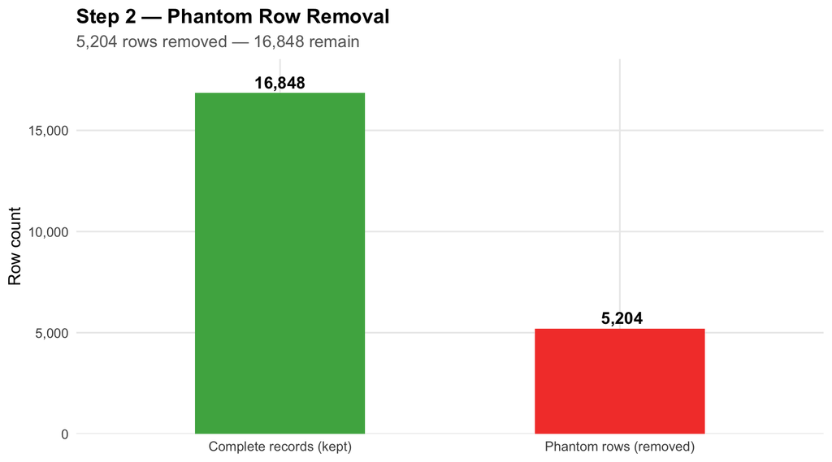

## 3.3 Step 3 — Standardise Column Names

| Original name | Renamed to |
| --- | --- |
| `Hu Start(0/1)` | `Hu_Start` |
| `hgb(g/dl)` | `hgb` |
| `rbc *10^12` | `rbc` |
| `Hb Genotype` | `hb_genotype` |
| `form.toxicity` | `toxicity` |
| `history.num_pain_events` | `num_pain_events` |
| `history.experienced_pain` | `experienced_pain` |

Columns that were already clean (e.g. `id_hu_study_number`, `platelet_count`) were left as-is.

## 3.4 Step 4 — Drop Columns That Should Never Be Used

**16** columns were removed:

| Column | Reason |
| --- | --- |
| hu_start_date | Target leakage — directly encodes the outcome |
| patient_full_name | PII — must never enter a model |
| patient_med_record_num | PII — must never enter a model |
| history.pain_history_notes | 98.8% empty; free text, not structured |
| Date Patient Registration | 92.9% empty; too sparse to use |
| Index | Bare row index, no clinical meaning |
| Column1 | Unnamed column, no clinical meaning |
| Column2 | Unnamed column, no clinical meaning |
| form.blood_test_results.select_labs | Form selector field, no clinical value |
| anc (SI Unit) / (Conv. Unit) | Duplicate unit variants of anc (keep primary) |
| arc (SI unit) / (Conv. unit) | Duplicate unit variants of arc (keep primary) |
| wbc (SI Unit) 10^9/L | Duplicate unit variant of wbc (keep primary) |
| hct (SI unit) / hct(%) | Duplicate unit variants of hct (keep primary) |

## 3.5 Step 5 — Filter to Laboratory Visits Only

The dataset contains three visit types. Only **Lab** visits carry blood test results — the others were excluded.

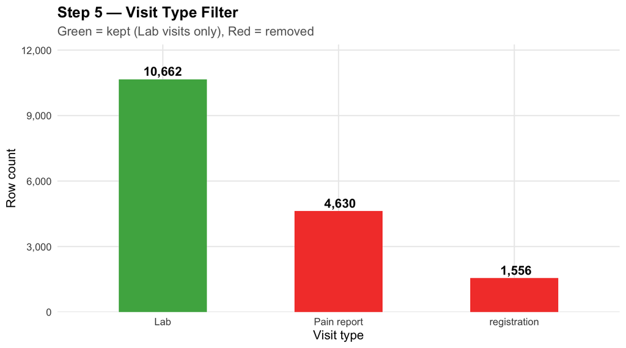

## 3.6 Step 6 — Remove Duplicates

After filtering to Lab visits, exact duplicate rows were removed using `duplicated()` across all columns simultaneously. A patient should not appear twice with identical information on the same date.

## 3.7 Step 7 — Convert and Standardise Data Types

[output not shown]

## 3.8 Step 8 — Handle Missing Lab Values

Missing values in all eight lab columns were replaced with the **column median** computed from the full dataset.

> **Important note:** This imputation uses all available rows because R’s role here is data preparation and descriptive reporting only — not model training. In Python, imputation will be recomputed on training rows only and then applied to the test set separately to prevent any data leakage across the train/test split.

## 3.9 Step 9 — Feature Engineering

Three new sets of features were created:

| Feature | Description |
| --- | --- |
| `age_group` | `"Paediatric"` (age < 18) or `"Adult"` (age ≥ 18) |
| `days_in_care` | Days elapsed since that patient’s first lab visit |
| `hgb_delta` | Difference between current Hgb and the patient’s baseline (first visit) Hgb |
| `hgb_prev` | Hgb value from the patient’s previous visit |
| `wbc_prev` | WBC value from the patient’s previous visit |
| `anc_prev` | ANC value from the patient’s previous visit |

For a patient’s first visit, `hgb_prev`, `wbc_prev`, and `anc_prev` are `NA` (no prior visit exists). These were filled with the column median.

# 4 Final Dataset — Summary

| Total rows (lab visits) | 10,632 |
| --- | --- |
| Total columns | 29 |
| Unique patients | 1,556 |
| Average visits per patient | 6.8 |
| Engineered features added | 6 |

# 5 Visualisations of the Final Clean Data

## 5.1 Outcome Distribution — Hu_Start

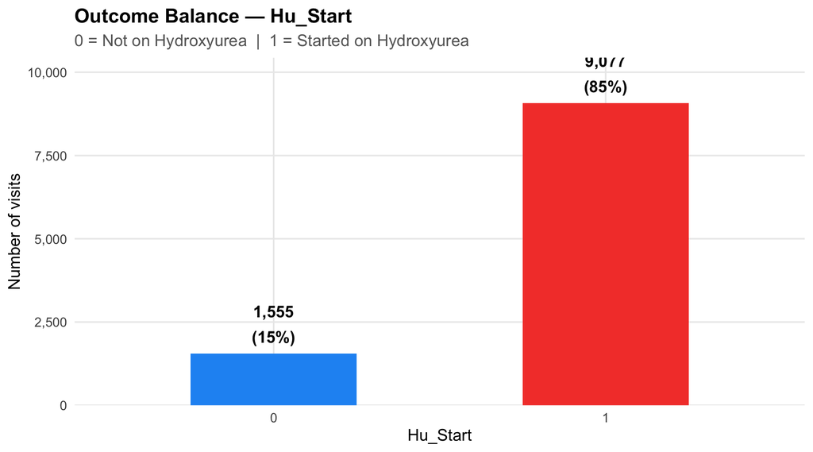

## 5.2 Age Distribution

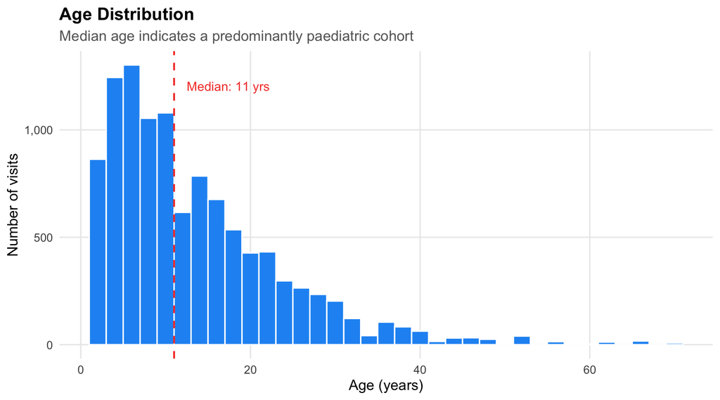

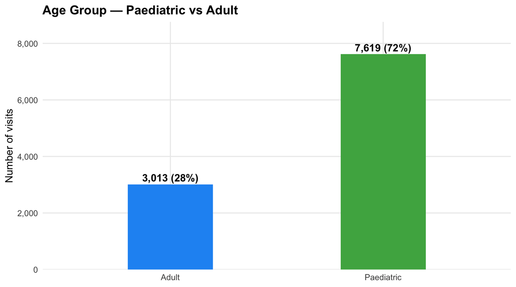

## 5.3 Gender Distribution

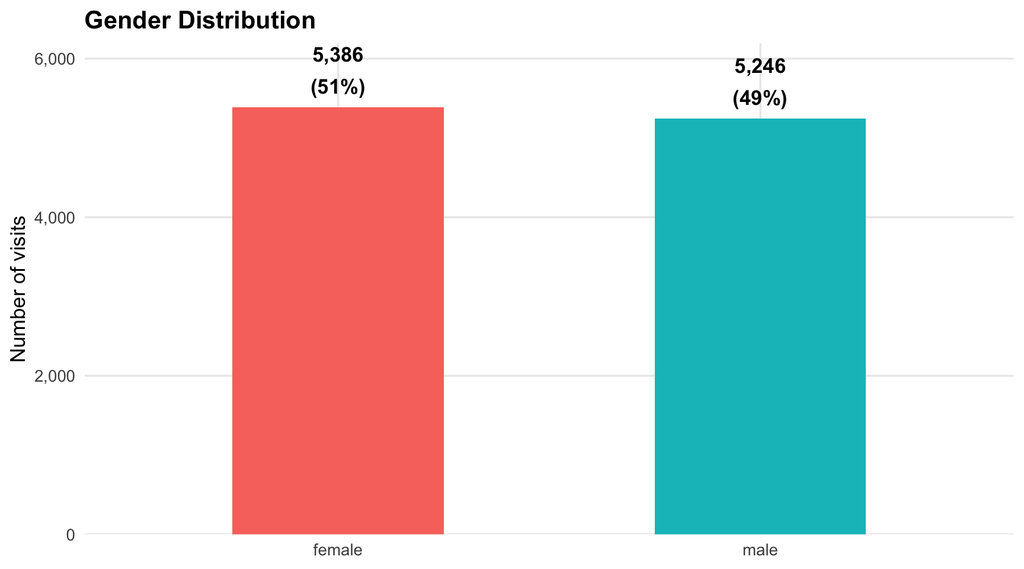

## 5.4 Hb Genotype Distribution

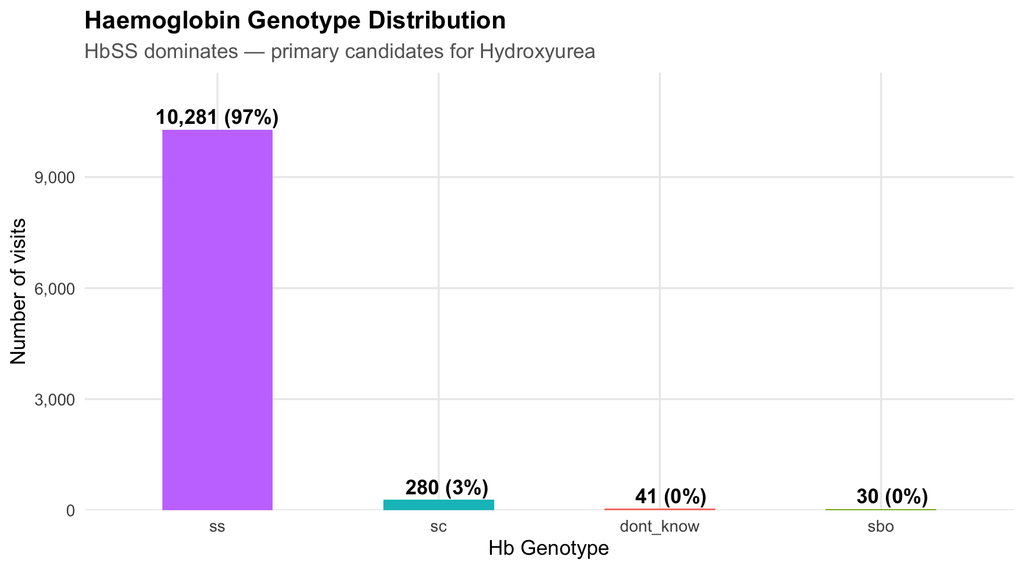

## 5.5 Facility Distribution

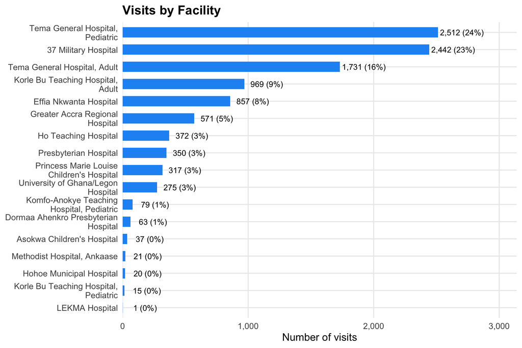

## 5.6 Laboratory Values — Distributions

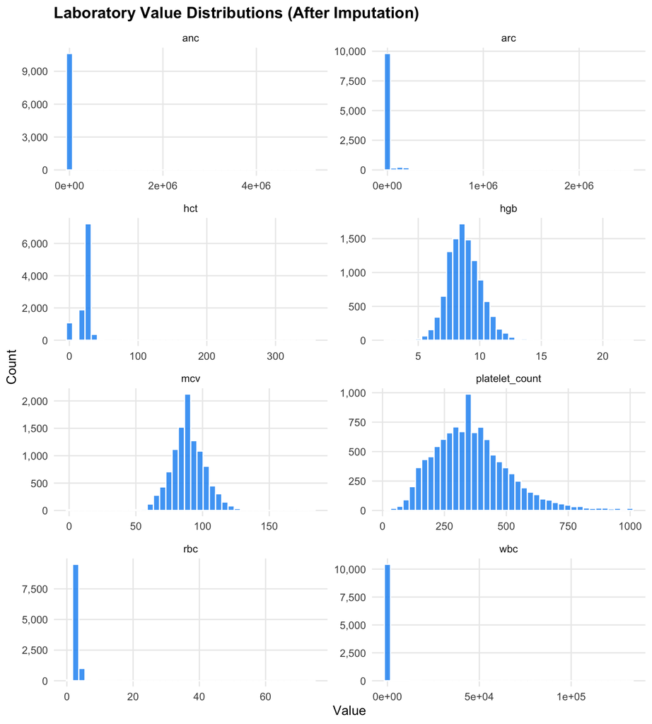

## 5.7 Laboratory Values — By Outcome Group

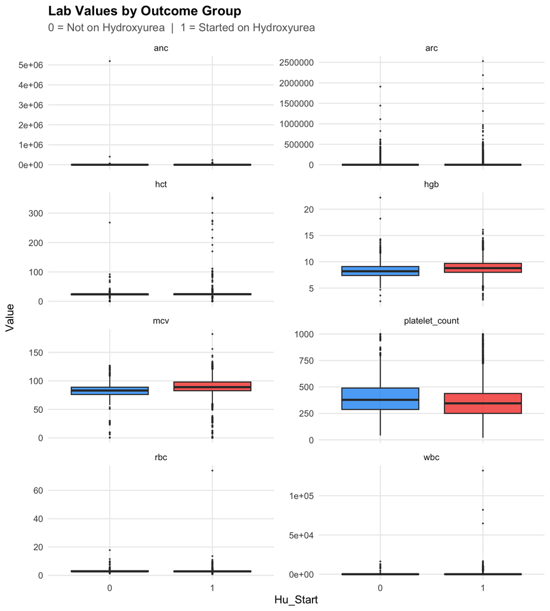

## 5.8 Engineered Features

[figure not shown]

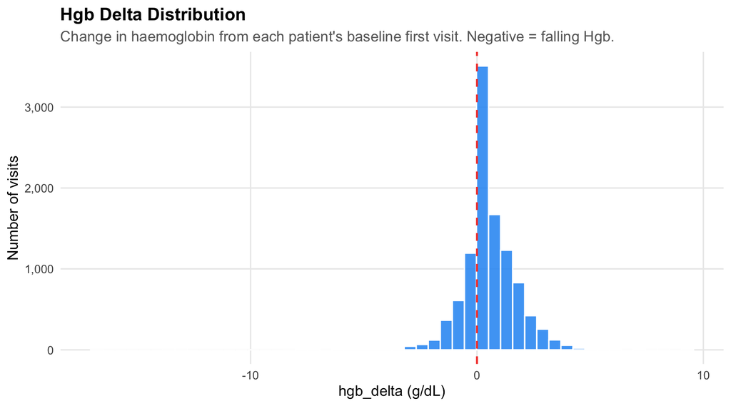

## 5.9 Toxicity Categories

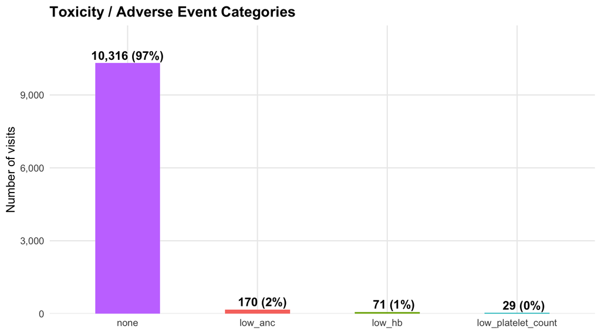

# 6 Table 1 — Patient Characteristics at Baseline

One row per patient (earliest lab visit). Stratified by Hu_Start outcome.

```
##                             Stratified by Hu_Start
##                              level
##   n
##   age (mean (SD))
##   hgb (mean (SD))
##   wbc (mean (SD))
##   anc (mean (SD))
##   platelet_count (mean (SD))
##   gender (%)                 female
##                              male
##   hb_genotype (%)            dont_know
##                              sbo
##                              sc
##                              ss
##   Facility_name (%)          37 Military Hospital
##                              Asokwa Children's Hospital
##                              Dormaa Ahenkro Presbyterian Hospital
##                              Effia Nkwanta Hospital
##                              Greater Accra Regional Hospital
##                              Ho Teaching Hospital
##                              Hohoe Municipal Hospital
##                              Komfo-Anokye Teaching Hospital, Pediatric
##                              Korle Bu Teaching Hospital, Adult
##                              Korle Bu Teaching Hospital, Pediatric
##                              LEKMA Hospital
##                              Methodist Hospital, Ankaase
##                              Presbyterian Hospital
##                              Princess Marie Louise Children's Hospital
##                              Tema General Hospital, Adult
##                              Tema General Hospital, Pediatric
##                              University of Ghana/Legon Hospital
##   Hu_Start (%)               0
##                              1
##                             Stratified by Hu_Start
##                              Overall             0
##   n                             1556                1546
##   age (mean (SD))              14.88 (10.50)       14.85 (10.47)
##   hgb (mean (SD))               8.33 (1.44)         8.33 (1.44)
##   wbc (mean (SD))              92.22 (890.69)      92.75 (893.54)
##   anc (mean (SD))            5136.19 (131991.93) 5151.43 (132417.98)
```

[output cut: 44 more lines]

```
##                                    0 (  0.0)
##                                    2 ( 20.0)
##                                    0 (  0.0)
##                                    0 (  0.0)
##                                    2 ( 20.0)
##                                    0 (  0.0)
##                                    0 (  0.0)
##                                    0 (  0.0)
##                                    1 ( 10.0)
##                                    0 (  0.0)
##                                    0 (  0.0)
##                                    1 ( 10.0)
##                                    0 (  0.0)
##   Hu_Start (%)                     0 (  0.0)   <0.001         NaN
##                                   10 (100.0)
```

# 7 Final Column Inventory

| Column | Type |
| --- | --- |
| Case_ID | character |
| Hu_Start | factor |
| id_hu_study_number | character |
| Facility_name | character |
| Clinic_Visit_Date | character |
| Lab_Visit_Date | character |
| Visit.type | character |
| Diagnosis.Method.Formatted | character |
| hb_genotype | factor |
| gender | factor |
| age | integer |
| dob | character |
| hgb | numeric |
| anc | numeric |
| arc | numeric |
| platelet_count | integer |
| wbc | numeric |
| rbc | numeric |
| mcv | numeric |
| hct | numeric |
| toxicity | factor |
| experienced_pain | logical |
| num_pain_events | logical |
| age_group | factor |
| days_in_care | numeric |
| hgb_delta | numeric |
| hgb_prev | numeric |
| wbc_prev | numeric |
| anc_prev | numeric |

*Report generated automatically from `data_cleaning.r` output.* *Working dataset: `ML/data/hu_clean_data.csv`*